# Deteccion de Anomalias conjunto de datos “Seismic-Bumps” (repositorio UCI)

```python
import pandas as pd
import numpy as np
import matplotlib.pyplot as plt
import pandas_profiling #funcion para ver missing values por variables en DF**
import seaborn as sns
from sklearn.preprocessing import StandardScaler
from  sklearn.pipeline import make_pipeline
from sklearn.preprocessing import LabelEncoder
from sklearn import preprocessing
from sklearn.cluster import KMeans
from sklearn.metrics import silhouette_samples, silhouette_score
from sklearn.cluster import DBSCAN
from sklearn.metrics.cluster import adjusted_rand_score
from sklearn.decomposition import PCA
from scipy.spatial.distance import cdist
from sklearn.ensemble import IsolationForest
from sklearn.svm import OneClassSVM
import mglearn
import warnings
warnings.filterwarnings('ignore')
import time
```

```python
def missing_values_table(df):
        mis_val = df.isnull().sum()
        mis_val_percent = 100 * df.isnull().sum()/len(df)
        mis_val_table = pd.concat([mis_val, mis_val_percent], axis=1)
        mis_val_table_ren_columns = mis_val_table.rename(
        columns = {0 : 'Missing Values', 1 : '% of Total Values'})
        return mis_val_table_ren_columns
```

## Data Processing

```python
df = pd.read_csv('seismic-bumps-2.csv')
```

```python
df.head()
```

|  | Fseismic | seismoacoustic | shift | genergy | gpuls | gdenergy | gdpuls | ghazard | nbumps | nbumps2 | nbumps3 | nbumps4 | nbumps5 | nbumps6 | nbumps7 | nbumps89 | energy | maxenergy | class |
| --- | --- | --- | --- | --- | --- | --- | --- | --- | --- | --- | --- | --- | --- | --- | --- | --- | --- | --- | --- |
| 0 | a | a | N | 15180.0 | 48.0 | -72.0 | -72.0 | a | 0.0 | 0.0 | 0.0 | 0.0 | 0.0 | 0.0 | 0.0 | 0.0 | 0.0 | 0.0 | 0 |
| 1 | a | a | N | 14720.0 | 33.0 | -70.0 | -79.0 | a | 1.0 | 0.0 | 1.0 | 0.0 | 0.0 | 0.0 | 0.0 | 0.0 | 2000.0 | 2000.0 | 0 |
| 2 | a | a | N | 8050.0 | 30.0 | -81.0 | -78.0 | a | 0.0 | 0.0 | 0.0 | 0.0 | 0.0 | 0.0 | 0.0 | 0.0 | 0.0 | 0.0 | 0 |
| 3 | a | a | N | 28820.0 | 171.0 | -23.0 | 40.0 | a | 1.0 | 0.0 | 1.0 | 0.0 | 0.0 | 0.0 | 0.0 | 0.0 | 3000.0 | 3000.0 | 0 |
| 4 | a | a | N | 12640.0 | 57.0 | -63.0 | -52.0 | a | 0.0 | 0.0 | 0.0 | 0.0 | 0.0 | 0.0 | 0.0 | 0.0 | 0.0 | 0.0 | 0 |

```python
#valores omitidos por variable
missing_values_table(df)
```

|  | Missing Values | % of Total Values |
| --- | --- | --- |
| Fseismic | 0 | 0.0 |
| seismoacoustic | 0 | 0.0 |
| shift | 0 | 0.0 |
| genergy | 0 | 0.0 |
| gpuls | 0 | 0.0 |
| gdenergy | 0 | 0.0 |
| gdpuls | 0 | 0.0 |
| ghazard | 0 | 0.0 |
| nbumps | 0 | 0.0 |
| nbumps2 | 0 | 0.0 |
| nbumps3 | 0 | 0.0 |
| nbumps4 | 0 | 0.0 |
| nbumps5 | 0 | 0.0 |
| nbumps6 | 0 | 0.0 |
| nbumps7 | 0 | 0.0 |
| nbumps89 | 0 | 0.0 |
| energy | 0 | 0.0 |
| maxenergy | 0 | 0.0 |
| class | 0 | 0.0 |

```python
#deteccion duplicados
df[df.duplicated()]
```

|  | Fseismic | seismoacoustic | shift | genergy | gpuls | gdenergy | gdpuls | ghazard | nbumps | nbumps2 | nbumps3 | nbumps4 | nbumps5 | nbumps6 | nbumps7 | nbumps89 | energy | maxenergy | class |
| --- | --- | --- | --- | --- | --- | --- | --- | --- | --- | --- | --- | --- | --- | --- | --- | --- | --- | --- | --- |
| 89 | a | a | N | 63550.0 | 325.0 | 15.0 | 35.0 | a | 0.0 | 0.0 | 0.0 | 0.0 | 0.0 | 0.0 | 0.0 | 0.0 | 0.0 | 0.0 | 0 |
| 90 | a | a | W | 194580.0 | 697.0 | -35.0 | -32.0 | a | 0.0 | 0.0 | 0.0 | 0.0 | 0.0 | 0.0 | 0.0 | 0.0 | 0.0 | 0.0 | 0 |
| 972 | a | b | N | 5250.0 | 66.0 | -49.0 | 36.0 | a | 0.0 | 0.0 | 0.0 | 0.0 | 0.0 | 0.0 | 0.0 | 0.0 | 0.0 | 0.0 | 0 |
| 973 | a | b | N | 19420.0 | 60.0 | 98.0 | 20.0 | a | 0.0 | 0.0 | 0.0 | 0.0 | 0.0 | 0.0 | 0.0 | 0.0 | 0.0 | 0.0 | 0 |
| 1017 | a | a | N | 590.0 | 11.0 | -74.0 | -72.0 | a | 0.0 | 0.0 | 0.0 | 0.0 | 0.0 | 0.0 | 0.0 | 0.0 | 0.0 | 0.0 | 0 |
| 1018 | a | a | N | 3720.0 | 43.0 | 75.0 | 8.0 | a | 0.0 | 0.0 | 0.0 | 0.0 | 0.0 | 0.0 | 0.0 | 0.0 | 0.0 | 0.0 | 0 |

```python
#Eliminacion Duplicados
data_new =df.drop_duplicates()
```

Overview

Dataset info

| Number of variables | 19 |
| --- | --- |
| Number of observations | 2584 |
| Total Missing (%) | 0.0% |
| Total size in memory | 383.6 KiB |
| Average record size in memory | 152.0 B |

Variables types

| Numeric | 9 |
| --- | --- |
| Categorical | 4 |
| Boolean | 2 |
| Date | 0 |
| Text (Unique) | 0 |
| Rejected | 4 |
| Unsupported | 0 |

Warnings

- `energy` has 1464 / 56.7% zeros Zeros

- `gdpuls` has 35 / 1.4% zeros Zeros

- `maxenergy` is highly correlated with `energy` (ρ = 0.98955) Rejected

- `nbumps` has 1464 / 56.7% zeros Zeros

- `nbumps2` has 1901 / 73.6% zeros Zeros

- `nbumps3` has 1879 / 72.7% zeros Zeros

- `nbumps4` has 2426 / 93.9% zeros Zeros

- `nbumps6` has constant value 0 Rejected

- `nbumps7` has constant value 0 Rejected

- `nbumps89` has constant value 0 Rejected

- Dataset has 6 duplicate rows Warning

Variables

Fseismic  
Categorical

| Distinct count | 2 |
| --- | --- |
| Unique (%) | 0.1% |
| Missing (%) | 0.0% |
| Missing (n) | 0 |

| a | 1682 |
| --- | --- |
| b | 902 |

Toggle details

| Value | Count | Frequency (%) |  |
| --- | --- | --- | --- |
| a | 1682 | 65.1% |  |
| b | 902 | 34.9% |  |

class  
Boolean

| Distinct count | 2 |
| --- | --- |
| Unique (%) | 0.1% |
| Missing (%) | 0.0% |
| Missing (n) | 0 |

| Mean | 0.065789 |
| --- | --- |

| 0 | 2414 |
| --- | --- |
| 1 | 170 |

Toggle details

| Value | Count | Frequency (%) |  |
| --- | --- | --- | --- |
| 0 | 2414 | 93.4% |  |
| 1 | 170 | 6.6% |  |

energy  
Numeric

| Distinct count | 242 |
| --- | --- |
| Unique (%) | 9.4% |
| Missing (%) | 0.0% |
| Missing (n) | 0 |
| Infinite (%) | 0.0% |
| Infinite (n) | 0 |

| Mean | 4975.3 |
| --- | --- |
| Minimum | 0 |
| Maximum | 402000 |
| Zeros (%) | 56.7% |

Toggle details

**Statistics**

Quantile statistics

| Minimum | 0 |
| --- | --- |
| 5-th percentile | 0 |
| Q1 | 0 |
| Median | 0 |
| Q3 | 2600 |
| 95-th percentile | 23000 |
| Maximum | 402000 |
| Range | 402000 |
| Interquartile range | 2600 |

Descriptive statistics

| Standard deviation | 20451 |
| --- | --- |
| Coef of variation | 4.1105 |
| Kurtosis | 132.34 |
| Mean | 4975.3 |
| MAD | 7347.2 |
| Skewness | 9.9413 |
| Sum | 12856000 |
| Variance | 418240000 |
| Memory size | 20.3 KiB |

**Histogram**

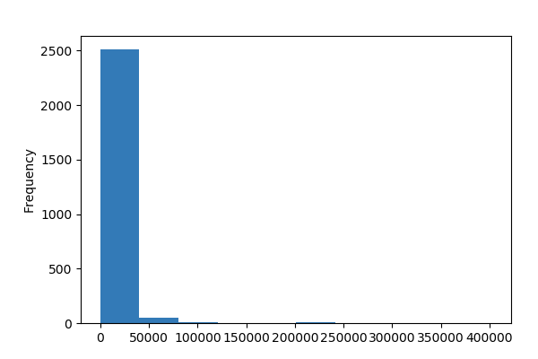

**Common Values**

| Value | Count | Frequency (%) |  |
| --- | --- | --- | --- |
| 0.0 | 1464 | 56.7% |  |
| 4000.0 | 70 | 2.7% |  |
| 3000.0 | 61 | 2.4% |  |
| 2000.0 | 58 | 2.2% |  |
| 300.0 | 48 | 1.9% |  |
| 400.0 | 46 | 1.8% |  |
| 1000.0 | 46 | 1.8% |  |
| 5000.0 | 40 | 1.5% |  |
| 200.0 | 37 | 1.4% |  |
| 600.0 | 36 | 1.4% |  |
| Other values (232) | 678 | 26.2% |  |

**Extreme Values**

Minimum 5 values

| Value | Count | Frequency (%) |  |
| --- | --- | --- | --- |
| 0.0 | 1464 | 56.7% |  |
| 50.0 | 1 | 0.0% |  |
| 100.0 | 14 | 0.5% |  |
| 200.0 | 37 | 1.4% |  |
| 250.0 | 1 | 0.0% |  |

Maximum 5 values

| Value | Count | Frequency (%) |  |
| --- | --- | --- | --- |
| 207900.0 | 1 | 0.0% |  |
| 208000.0 | 1 | 0.0% |  |
| 300000.0 | 2 | 0.1% |  |
| 303000.0 | 1 | 0.0% |  |
| 402000.0 | 1 | 0.0% |  |

gdenergy  
Numeric

| Distinct count | 334 |
| --- | --- |
| Unique (%) | 12.9% |
| Missing (%) | 0.0% |
| Missing (n) | 0 |
| Infinite (%) | 0.0% |
| Infinite (n) | 0 |

| Mean | 12.376 |
| --- | --- |
| Minimum | -96 |
| Maximum | 1245 |
| Zeros (%) | 0.9% |

Toggle details

**Statistics**

Quantile statistics

| Minimum | -96 |
| --- | --- |
| 5-th percentile | -71 |
| Q1 | -37 |
| Median | -6 |
| Q3 | 38 |
| 95-th percentile | 156.7 |
| Maximum | 1245 |
| Range | 1341 |
| Interquartile range | 75 |

Descriptive statistics

| Standard deviation | 80.319 |
| --- | --- |
| Coef of variation | 6.49 |
| Kurtosis | 29.364 |
| Mean | 12.376 |
| MAD | 54.232 |
| Skewness | 3.4075 |
| Sum | 31979 |
| Variance | 6451.1 |
| Memory size | 20.3 KiB |

**Histogram**

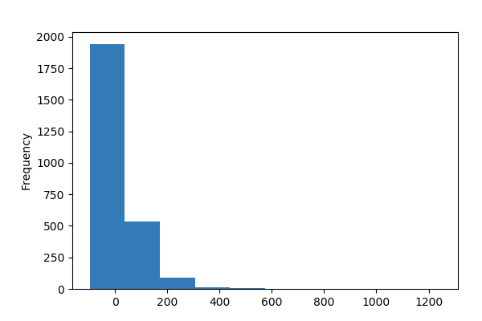

**Common Values**

| Value | Count | Frequency (%) |  |
| --- | --- | --- | --- |
| -14.0 | 29 | 1.1% |  |
| -32.0 | 28 | 1.1% |  |
| -7.0 | 26 | 1.0% |  |
| -31.0 | 25 | 1.0% |  |
| -42.0 | 25 | 1.0% |  |
| -10.0 | 25 | 1.0% |  |
| -38.0 | 25 | 1.0% |  |
| -20.0 | 24 | 0.9% |  |
| -40.0 | 24 | 0.9% |  |
| 0.0 | 23 | 0.9% |  |
| Other values (324) | 2330 | 90.2% |  |

**Extreme Values**

Minimum 5 values

| Value | Count | Frequency (%) |  |
| --- | --- | --- | --- |
| -96.0 | 2 | 0.1% |  |
| -95.0 | 2 | 0.1% |  |
| -94.0 | 3 | 0.1% |  |
| -93.0 | 1 | 0.0% |  |
| -92.0 | 1 | 0.0% |  |

Maximum 5 values

| Value | Count | Frequency (%) |  |
| --- | --- | --- | --- |
| 517.0 | 1 | 0.0% |  |
| 626.0 | 1 | 0.0% |  |
| 668.0 | 1 | 0.0% |  |
| 681.0 | 1 | 0.0% |  |
| 1245.0 | 1 | 0.0% |  |

gdpuls  
Numeric

| Distinct count | 292 |
| --- | --- |
| Unique (%) | 11.3% |
| Missing (%) | 0.0% |
| Missing (n) | 0 |
| Infinite (%) | 0.0% |
| Infinite (n) | 0 |

| Mean | 4.5089 |
| --- | --- |
| Minimum | -96 |
| Maximum | 838 |
| Zeros (%) | 1.4% |

Toggle details

**Statistics**

Quantile statistics

| Minimum | -96 |
| --- | --- |
| 5-th percentile | -70 |
| Q1 | -36 |
| Median | -6 |
| Q3 | 30.25 |
| 95-th percentile | 110.85 |
| Maximum | 838 |
| Range | 934 |
| Interquartile range | 66.25 |

Descriptive statistics

| Standard deviation | 63.167 |
| --- | --- |
| Coef of variation | 14.009 |
| Kurtosis | 17.372 |
| Mean | 4.5089 |
| MAD | 44.284 |
| Skewness | 2.5588 |
| Sum | 11651 |
| Variance | 3990 |
| Memory size | 20.3 KiB |

**Histogram**

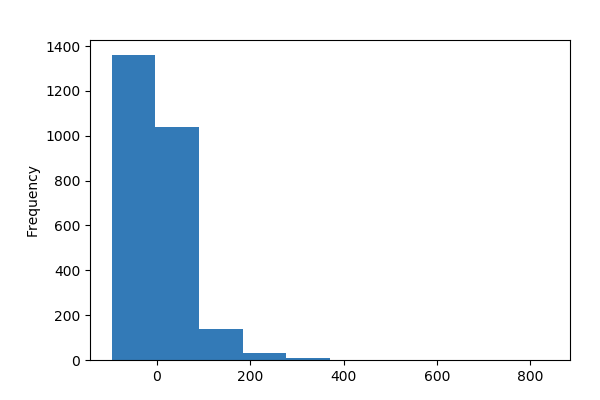

**Common Values**

| Value | Count | Frequency (%) |  |
| --- | --- | --- | --- |
| -32.0 | 35 | 1.4% |  |
| 0.0 | 35 | 1.4% |  |
| -14.0 | 30 | 1.2% |  |
| -28.0 | 29 | 1.1% |  |
| 6.0 | 29 | 1.1% |  |
| 2.0 | 29 | 1.1% |  |
| -42.0 | 27 | 1.0% |  |
| -6.0 | 26 | 1.0% |  |
| -2.0 | 26 | 1.0% |  |
| -40.0 | 26 | 1.0% |  |
| Other values (282) | 2292 | 88.7% |  |

**Extreme Values**

Minimum 5 values

| Value | Count | Frequency (%) |  |
| --- | --- | --- | --- |
| -96.0 | 2 | 0.1% |  |
| -95.0 | 1 | 0.0% |  |
| -92.0 | 3 | 0.1% |  |
| -91.0 | 1 | 0.0% |  |
| -90.0 | 5 | 0.2% |  |

Maximum 5 values

| Value | Count | Frequency (%) |  |
| --- | --- | --- | --- |
| 367.0 | 1 | 0.0% |  |
| 384.0 | 1 | 0.0% |  |
| 450.0 | 1 | 0.0% |  |
| 506.0 | 1 | 0.0% |  |
| 838.0 | 1 | 0.0% |  |

genergy  
Numeric

| Distinct count | 2212 |
| --- | --- |
| Unique (%) | 85.6% |
| Missing (%) | 0.0% |
| Missing (n) | 0 |
| Infinite (%) | 0.0% |
| Infinite (n) | 0 |

| Mean | 90243 |
| --- | --- |
| Minimum | 100 |
| Maximum | 2595600 |
| Zeros (%) | 0.0% |

Toggle details

**Statistics**

Quantile statistics

| Minimum | 100 |
| --- | --- |
| 5-th percentile | 3210 |
| Q1 | 11660 |
| Median | 25485 |
| Q3 | 52832 |
| 95-th percentile | 463460 |
| Maximum | 2595600 |
| Range | 2595600 |
| Interquartile range | 41172 |

Descriptive statistics

| Standard deviation | 229200 |
| --- | --- |
| Coef of variation | 2.5398 |
| Kurtosis | 32.556 |
| Mean | 90243 |
| MAD | 109540 |
| Skewness | 5.168 |
| Sum | 233190000 |
| Variance | 52533000000 |
| Memory size | 20.3 KiB |

**Histogram**

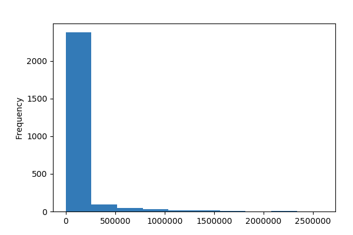

**Common Values**

| Value | Count | Frequency (%) |  |
| --- | --- | --- | --- |
| 7400.0 | 5 | 0.2% |  |
| 19420.0 | 4 | 0.2% |  |
| 3610.0 | 4 | 0.2% |  |
| 6790.0 | 4 | 0.2% |  |
| 20160.0 | 4 | 0.2% |  |
| 15300.0 | 4 | 0.2% |  |
| 11230.0 | 4 | 0.2% |  |
| 9450.0 | 3 | 0.1% |  |
| 6980.0 | 3 | 0.1% |  |
| 25050.0 | 3 | 0.1% |  |
| Other values (2202) | 2546 | 98.5% |  |

**Extreme Values**

Minimum 5 values

| Value | Count | Frequency (%) |  |
| --- | --- | --- | --- |
| 100.0 | 1 | 0.0% |  |
| 290.0 | 1 | 0.0% |  |
| 340.0 | 1 | 0.0% |  |
| 430.0 | 1 | 0.0% |  |
| 500.0 | 1 | 0.0% |  |

Maximum 5 values

| Value | Count | Frequency (%) |  |
| --- | --- | --- | --- |
| 2102300.0 | 1 | 0.0% |  |
| 2129020.0 | 1 | 0.0% |  |
| 2160800.0 | 1 | 0.0% |  |
| 2196220.0 | 1 | 0.0% |  |
| 2595650.0 | 1 | 0.0% |  |

ghazard  
Categorical

| Distinct count | 3 |
| --- | --- |
| Unique (%) | 0.1% |
| Missing (%) | 0.0% |
| Missing (n) | 0 |

| a | 2342 |
| --- | --- |
| b | 212 |
| c | 30 |

Toggle details

| Value | Count | Frequency (%) |  |
| --- | --- | --- | --- |
| a | 2342 | 90.6% |  |
| b | 212 | 8.2% |  |
| c | 30 | 1.2% |  |

gpuls  
Numeric

| Distinct count | 1128 |
| --- | --- |
| Unique (%) | 43.7% |
| Missing (%) | 0.0% |
| Missing (n) | 0 |
| Infinite (%) | 0.0% |
| Infinite (n) | 0 |

| Mean | 538.58 |
| --- | --- |
| Minimum | 2 |
| Maximum | 4518 |
| Zeros (%) | 0.0% |

Toggle details

**Statistics**

Quantile statistics

| Minimum | 2 |
| --- | --- |
| 5-th percentile | 28 |
| Q1 | 190 |
| Median | 379 |
| Q3 | 669 |
| 95-th percentile | 1712.2 |
| Maximum | 4518 |
| Range | 4516 |
| Interquartile range | 479 |

Descriptive statistics

| Standard deviation | 562.65 |
| --- | --- |
| Coef of variation | 1.0447 |
| Kurtosis | 8.2852 |
| Mean | 538.58 |
| MAD | 380.29 |
| Skewness | 2.4791 |
| Sum | 1391700 |
| Variance | 316580 |
| Memory size | 20.3 KiB |

**Histogram**

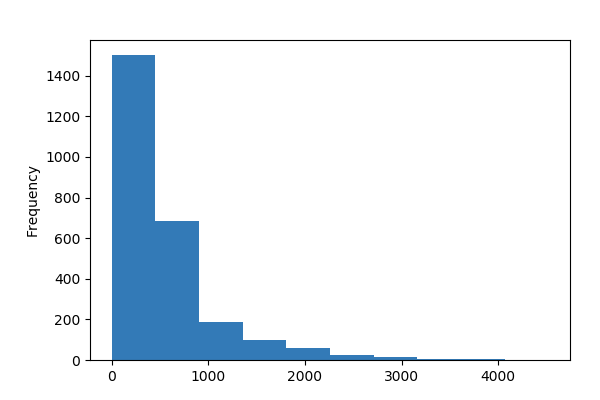

**Common Values**

| Value | Count | Frequency (%) |  |
| --- | --- | --- | --- |
| 19.0 | 12 | 0.5% |  |
| 46.0 | 9 | 0.3% |  |
| 213.0 | 9 | 0.3% |  |
| 17.0 | 9 | 0.3% |  |
| 25.0 | 8 | 0.3% |  |
| 262.0 | 8 | 0.3% |  |
| 112.0 | 8 | 0.3% |  |
| 133.0 | 8 | 0.3% |  |
| 402.0 | 8 | 0.3% |  |
| 24.0 | 8 | 0.3% |  |
| Other values (1118) | 2497 | 96.6% |  |

**Extreme Values**

Minimum 5 values

| Value | Count | Frequency (%) |  |
| --- | --- | --- | --- |
| 2.0 | 1 | 0.0% |  |
| 3.0 | 2 | 0.1% |  |
| 4.0 | 2 | 0.1% |  |
| 6.0 | 6 | 0.2% |  |
| 7.0 | 4 | 0.2% |  |

Maximum 5 values

| Value | Count | Frequency (%) |  |
| --- | --- | --- | --- |
| 3848.0 | 1 | 0.0% |  |
| 3915.0 | 1 | 0.0% |  |
| 4014.0 | 1 | 0.0% |  |
| 4365.0 | 1 | 0.0% |  |
| 4518.0 | 1 | 0.0% |  |

maxenergy  
Highly correlated

*This variable is highly correlated with `energy` and should be ignored for analysis*

| Correlation | 0.98955 |
| --- | --- |

nbumps  
Numeric

| Distinct count | 10 |
| --- | --- |
| Unique (%) | 0.4% |
| Missing (%) | 0.0% |
| Missing (n) | 0 |
| Infinite (%) | 0.0% |
| Infinite (n) | 0 |

| Mean | 0.85952 |
| --- | --- |
| Minimum | 0 |
| Maximum | 9 |
| Zeros (%) | 56.7% |

Toggle details

**Statistics**

Quantile statistics

| Minimum | 0 |
| --- | --- |
| 5-th percentile | 0 |
| Q1 | 0 |
| Median | 0 |
| Q3 | 1 |
| 95-th percentile | 4 |
| Maximum | 9 |
| Range | 9 |
| Interquartile range | 1 |

Descriptive statistics

| Standard deviation | 1.3646 |
| --- | --- |
| Coef of variation | 1.5876 |
| Kurtosis | 5.9253 |
| Mean | 0.85952 |
| MAD | 0.97395 |
| Skewness | 2.2326 |
| Sum | 2221 |
| Variance | 1.8622 |
| Memory size | 20.3 KiB |

**Histogram**

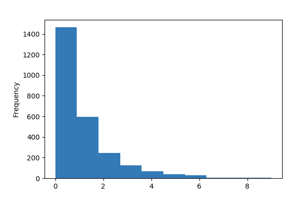

**Common Values**

| Value | Count | Frequency (%) |  |
| --- | --- | --- | --- |
| 0.0 | 1464 | 56.7% |  |
| 1.0 | 598 | 23.1% |  |
| 2.0 | 245 | 9.5% |  |
| 3.0 | 127 | 4.9% |  |
| 4.0 | 69 | 2.7% |  |
| 5.0 | 38 | 1.5% |  |
| 6.0 | 28 | 1.1% |  |
| 8.0 | 7 | 0.3% |  |
| 7.0 | 5 | 0.2% |  |
| 9.0 | 3 | 0.1% |  |

**Extreme Values**

Minimum 5 values

| Value | Count | Frequency (%) |  |
| --- | --- | --- | --- |
| 0.0 | 1464 | 56.7% |  |
| 1.0 | 598 | 23.1% |  |
| 2.0 | 245 | 9.5% |  |
| 3.0 | 127 | 4.9% |  |
| 4.0 | 69 | 2.7% |  |

Maximum 5 values

| Value | Count | Frequency (%) |  |
| --- | --- | --- | --- |
| 5.0 | 38 | 1.5% |  |
| 6.0 | 28 | 1.1% |  |
| 7.0 | 5 | 0.2% |  |
| 8.0 | 7 | 0.3% |  |
| 9.0 | 3 | 0.1% |  |

nbumps2  
Numeric

| Distinct count | 7 |
| --- | --- |
| Unique (%) | 0.3% |
| Missing (%) | 0.0% |
| Missing (n) | 0 |
| Infinite (%) | 0.0% |
| Infinite (n) | 0 |

| Mean | 0.39358 |
| --- | --- |
| Minimum | 0 |
| Maximum | 8 |
| Zeros (%) | 73.6% |

Toggle details

**Statistics**

Quantile statistics

| Minimum | 0 |
| --- | --- |
| 5-th percentile | 0 |
| Q1 | 0 |
| Median | 0 |
| Q3 | 1 |
| 95-th percentile | 2 |
| Maximum | 8 |
| Range | 8 |
| Interquartile range | 1 |

Descriptive statistics

| Standard deviation | 0.78377 |
| --- | --- |
| Coef of variation | 1.9914 |
| Kurtosis | 9.201 |
| Mean | 0.39358 |
| MAD | 0.57909 |
| Skewness | 2.5976 |
| Sum | 1017 |
| Variance | 0.6143 |
| Memory size | 20.3 KiB |

**Histogram**

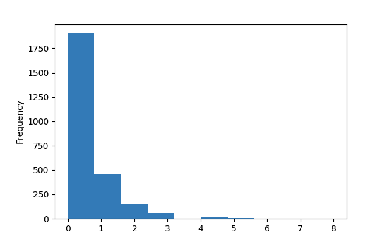

**Common Values**

| Value | Count | Frequency (%) |  |
| --- | --- | --- | --- |
| 0.0 | 1901 | 73.6% |  |
| 1.0 | 455 | 17.6% |  |
| 2.0 | 151 | 5.8% |  |
| 3.0 | 58 | 2.2% |  |
| 4.0 | 12 | 0.5% |  |
| 5.0 | 6 | 0.2% |  |
| 8.0 | 1 | 0.0% |  |

**Extreme Values**

Minimum 5 values

| Value | Count | Frequency (%) |  |
| --- | --- | --- | --- |
| 0.0 | 1901 | 73.6% |  |
| 1.0 | 455 | 17.6% |  |
| 2.0 | 151 | 5.8% |  |
| 3.0 | 58 | 2.2% |  |
| 4.0 | 12 | 0.5% |  |

Maximum 5 values

| Value | Count | Frequency (%) |  |
| --- | --- | --- | --- |
| 2.0 | 151 | 5.8% |  |
| 3.0 | 58 | 2.2% |  |
| 4.0 | 12 | 0.5% |  |
| 5.0 | 6 | 0.2% |  |
| 8.0 | 1 | 0.0% |  |

nbumps3  
Numeric

| Distinct count | 7 |
| --- | --- |
| Unique (%) | 0.3% |
| Missing (%) | 0.0% |
| Missing (n) | 0 |
| Infinite (%) | 0.0% |
| Infinite (n) | 0 |

| Mean | 0.3928 |
| --- | --- |
| Minimum | 0 |
| Maximum | 7 |
| Zeros (%) | 72.7% |

Toggle details

**Statistics**

Quantile statistics

| Minimum | 0 |
| --- | --- |
| 5-th percentile | 0 |
| Q1 | 0 |
| Median | 0 |
| Q3 | 1 |
| 95-th percentile | 2 |
| Maximum | 7 |
| Range | 7 |
| Interquartile range | 1 |

Descriptive statistics

| Standard deviation | 0.76971 |
| --- | --- |
| Coef of variation | 1.9595 |
| Kurtosis | 8.6399 |
| Mean | 0.3928 |
| MAD | 0.57127 |
| Skewness | 2.5821 |
| Sum | 1015 |
| Variance | 0.59245 |
| Memory size | 20.3 KiB |

**Histogram**

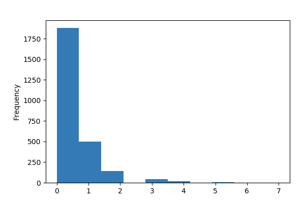

**Common Values**

| Value | Count | Frequency (%) |  |
| --- | --- | --- | --- |
| 0.0 | 1879 | 72.7% |  |
| 1.0 | 497 | 19.2% |  |
| 2.0 | 140 | 5.4% |  |
| 3.0 | 42 | 1.6% |  |
| 4.0 | 20 | 0.8% |  |
| 5.0 | 5 | 0.2% |  |
| 7.0 | 1 | 0.0% |  |

**Extreme Values**

Minimum 5 values

| Value | Count | Frequency (%) |  |
| --- | --- | --- | --- |
| 0.0 | 1879 | 72.7% |  |
| 1.0 | 497 | 19.2% |  |
| 2.0 | 140 | 5.4% |  |
| 3.0 | 42 | 1.6% |  |
| 4.0 | 20 | 0.8% |  |

Maximum 5 values

| Value | Count | Frequency (%) |  |
| --- | --- | --- | --- |
| 2.0 | 140 | 5.4% |  |
| 3.0 | 42 | 1.6% |  |
| 4.0 | 20 | 0.8% |  |
| 5.0 | 5 | 0.2% |  |
| 7.0 | 1 | 0.0% |  |

nbumps4  
Numeric

| Distinct count | 4 |
| --- | --- |
| Unique (%) | 0.2% |
| Missing (%) | 0.0% |
| Missing (n) | 0 |
| Infinite (%) | 0.0% |
| Infinite (n) | 0 |

| Mean | 0.067724 |
| --- | --- |
| Minimum | 0 |
| Maximum | 3 |
| Zeros (%) | 93.9% |

Toggle details

**Statistics**

Quantile statistics

| Minimum | 0 |
| --- | --- |
| 5-th percentile | 0 |
| Q1 | 0 |
| Median | 0 |
| Q3 | 0 |
| 95-th percentile | 1 |
| Maximum | 3 |
| Range | 3 |
| Interquartile range | 0 |

Descriptive statistics

| Standard deviation | 0.27906 |
| --- | --- |
| Coef of variation | 4.1205 |
| Kurtosis | 24.97 |
| Mean | 0.067724 |
| MAD | 0.12717 |
| Skewness | 4.6236 |
| Sum | 175 |
| Variance | 0.077874 |
| Memory size | 20.3 KiB |

**Histogram**

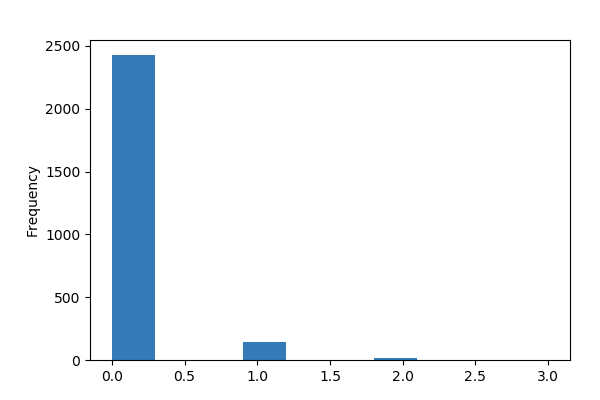

**Common Values**

| Value | Count | Frequency (%) |  |
| --- | --- | --- | --- |
| 0.0 | 2426 | 93.9% |  |
| 1.0 | 143 | 5.5% |  |
| 2.0 | 13 | 0.5% |  |
| 3.0 | 2 | 0.1% |  |

**Extreme Values**

Minimum 5 values

| Value | Count | Frequency (%) |  |
| --- | --- | --- | --- |
| 0.0 | 2426 | 93.9% |  |
| 1.0 | 143 | 5.5% |  |
| 2.0 | 13 | 0.5% |  |
| 3.0 | 2 | 0.1% |  |

Maximum 5 values

| Value | Count | Frequency (%) |  |
| --- | --- | --- | --- |
| 0.0 | 2426 | 93.9% |  |
| 1.0 | 143 | 5.5% |  |
| 2.0 | 13 | 0.5% |  |
| 3.0 | 2 | 0.1% |  |

nbumps5  
Boolean

| Distinct count | 2 |
| --- | --- |
| Unique (%) | 0.1% |
| Missing (%) | 0.0% |
| Missing (n) | 0 |

| Mean | 0.004644 |
| --- | --- |

| 0.0 | 2572 |
| --- | --- |
| 1.0 | 12 |

Toggle details

| Value | Count | Frequency (%) |  |
| --- | --- | --- | --- |
| 0.0 | 2572 | 99.5% |  |
| 1.0 | 12 | 0.5% |  |

nbumps6  
Constant

*This variable is constant and should be ignored for analysis*

| Constant value | 0 |
| --- | --- |

nbumps7  
Constant

*This variable is constant and should be ignored for analysis*

| Constant value | 0 |
| --- | --- |

nbumps89  
Constant

*This variable is constant and should be ignored for analysis*

| Constant value | 0 |
| --- | --- |

seismoacoustic  
Categorical

| Distinct count | 3 |
| --- | --- |
| Unique (%) | 0.1% |
| Missing (%) | 0.0% |
| Missing (n) | 0 |

| a | 1580 |
| --- | --- |
| b | 956 |
| c | 48 |

Toggle details

| Value | Count | Frequency (%) |  |
| --- | --- | --- | --- |
| a | 1580 | 61.1% |  |
| b | 956 | 37.0% |  |
| c | 48 | 1.9% |  |

shift  
Categorical

| Distinct count | 2 |
| --- | --- |
| Unique (%) | 0.1% |
| Missing (%) | 0.0% |
| Missing (n) | 0 |

| W | 1663 |
| --- | --- |
| N | 921 |

Toggle details

| Value | Count | Frequency (%) |  |
| --- | --- | --- | --- |
| W | 1663 | 64.4% |  |
| N | 921 | 35.6% |  |

Correlations

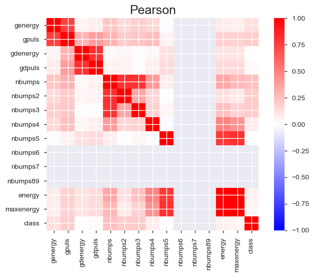

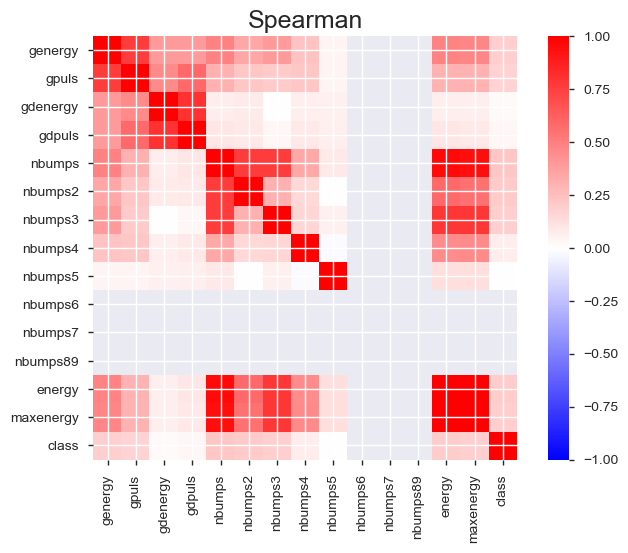

Sample

|  | Fseismic | seismoacoustic | shift | genergy | gpuls | gdenergy | gdpuls | ghazard | nbumps | nbumps2 | nbumps3 | nbumps4 | nbumps5 | nbumps6 | nbumps7 | nbumps89 | energy | maxenergy | class |
| --- | --- | --- | --- | --- | --- | --- | --- | --- | --- | --- | --- | --- | --- | --- | --- | --- | --- | --- | --- |
| 0 | a | a | N | 15180.0 | 48.0 | -72.0 | -72.0 | a | 0.0 | 0.0 | 0.0 | 0.0 | 0.0 | 0.0 | 0.0 | 0.0 | 0.0 | 0.0 | 0 |
| 1 | a | a | N | 14720.0 | 33.0 | -70.0 | -79.0 | a | 1.0 | 0.0 | 1.0 | 0.0 | 0.0 | 0.0 | 0.0 | 0.0 | 2000.0 | 2000.0 | 0 |
| 2 | a | a | N | 8050.0 | 30.0 | -81.0 | -78.0 | a | 0.0 | 0.0 | 0.0 | 0.0 | 0.0 | 0.0 | 0.0 | 0.0 | 0.0 | 0.0 | 0 |
| 3 | a | a | N | 28820.0 | 171.0 | -23.0 | 40.0 | a | 1.0 | 0.0 | 1.0 | 0.0 | 0.0 | 0.0 | 0.0 | 0.0 | 3000.0 | 3000.0 | 0 |
| 4 | a | a | N | 12640.0 | 57.0 | -63.0 | -52.0 | a | 0.0 | 0.0 | 0.0 | 0.0 | 0.0 | 0.0 | 0.0 | 0.0 | 0.0 | 0.0 | 0 |

```python
#Estadicas por variable
pandas_profiling.ProfileReport(df)
```

```python
#No se eliman columnas correlacionadas se utilizara PCA
data_full = df.copy()
#df.drop(['energy','nbumps6','nbumps7','nbumps89','class'], axis=1)
```

```python
#Eliminacion Atributo Clase
df = df.drop(['class'],axis=1)
```

```python
df.head()
```

|  | Fseismic | seismoacoustic | shift | genergy | gpuls | gdenergy | gdpuls | ghazard | nbumps | nbumps2 | nbumps3 | nbumps4 | nbumps5 | nbumps6 | nbumps7 | nbumps89 | energy | maxenergy |
| --- | --- | --- | --- | --- | --- | --- | --- | --- | --- | --- | --- | --- | --- | --- | --- | --- | --- | --- |
| 0 | a | a | N | 15180.0 | 48.0 | -72.0 | -72.0 | a | 0.0 | 0.0 | 0.0 | 0.0 | 0.0 | 0.0 | 0.0 | 0.0 | 0.0 | 0.0 |
| 1 | a | a | N | 14720.0 | 33.0 | -70.0 | -79.0 | a | 1.0 | 0.0 | 1.0 | 0.0 | 0.0 | 0.0 | 0.0 | 0.0 | 2000.0 | 2000.0 |
| 2 | a | a | N | 8050.0 | 30.0 | -81.0 | -78.0 | a | 0.0 | 0.0 | 0.0 | 0.0 | 0.0 | 0.0 | 0.0 | 0.0 | 0.0 | 0.0 |
| 3 | a | a | N | 28820.0 | 171.0 | -23.0 | 40.0 | a | 1.0 | 0.0 | 1.0 | 0.0 | 0.0 | 0.0 | 0.0 | 0.0 | 3000.0 | 3000.0 |
| 4 | a | a | N | 12640.0 | 57.0 | -63.0 | -52.0 | a | 0.0 | 0.0 | 0.0 | 0.0 | 0.0 | 0.0 | 0.0 | 0.0 | 0.0 | 0.0 |

```python
#Numerizar varibles object
for c in df.columns:
        if df[c].dtype == 'object':
            lbl = preprocessing.LabelEncoder()
            lbl.fit(list(df[c].values))
            df[c] = lbl.transform(list(df[c].values))
df.head()
```

|  | Fseismic | seismoacoustic | shift | genergy | gpuls | gdenergy | gdpuls | ghazard | nbumps | nbumps2 | nbumps3 | nbumps4 | nbumps5 | nbumps6 | nbumps7 | nbumps89 | energy | maxenergy |
| --- | --- | --- | --- | --- | --- | --- | --- | --- | --- | --- | --- | --- | --- | --- | --- | --- | --- | --- |
| 0 | 0 | 0 | 0 | 15180.0 | 48.0 | -72.0 | -72.0 | 0 | 0.0 | 0.0 | 0.0 | 0.0 | 0.0 | 0.0 | 0.0 | 0.0 | 0.0 | 0.0 |
| 1 | 0 | 0 | 0 | 14720.0 | 33.0 | -70.0 | -79.0 | 0 | 1.0 | 0.0 | 1.0 | 0.0 | 0.0 | 0.0 | 0.0 | 0.0 | 2000.0 | 2000.0 |
| 2 | 0 | 0 | 0 | 8050.0 | 30.0 | -81.0 | -78.0 | 0 | 0.0 | 0.0 | 0.0 | 0.0 | 0.0 | 0.0 | 0.0 | 0.0 | 0.0 | 0.0 |
| 3 | 0 | 0 | 0 | 28820.0 | 171.0 | -23.0 | 40.0 | 0 | 1.0 | 0.0 | 1.0 | 0.0 | 0.0 | 0.0 | 0.0 | 0.0 | 3000.0 | 3000.0 |
| 4 | 0 | 0 | 0 | 12640.0 | 57.0 | -63.0 | -52.0 | 0 | 0.0 | 0.0 | 0.0 | 0.0 | 0.0 | 0.0 | 0.0 | 0.0 | 0.0 | 0.0 |

## Mediante K-Means

#### Numero Optimo de Clusters Elbow Curve

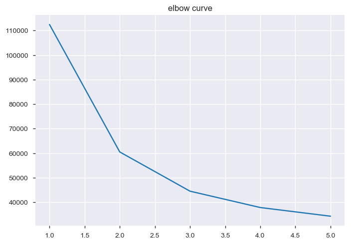

```python
res = list()
n_cluster = range(1,6)
for n in n_cluster:
    kmeans = KMeans(n_clusters=n)
    kmeans.fit(df)
    res.append(np.average(np.min(cdist(df, kmeans.cluster_centers_, 'euclidean'), axis=1)))

plt.plot(n_cluster, res)
plt.title('elbow curve')
plt.show()
```

#### PCA 3 Componentes

```python
pca = PCA(n_components=3)
X = pca.fit_transform(df)
```

#### Distribucion Clusters K-means 3D

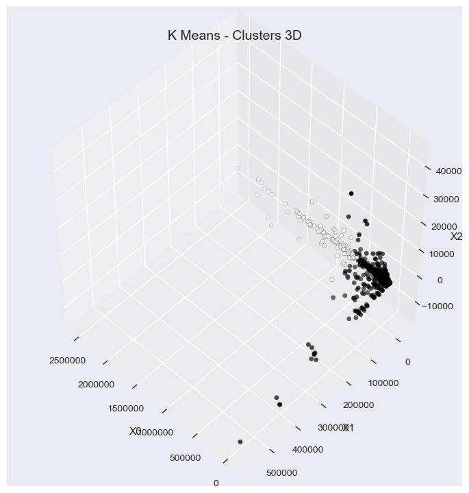

```python
from mpl_toolkits.mplot3d import Axes3D, axes3d
km = KMeans(n_clusters=2)
km.fit(X)
km.predict(X)
labels = km.labels_
#Plotting
fig = plt.figure(1, figsize=(7,7))
ax = Axes3D(fig, rect=[0, 0, 0.95, 1], elev=48, azim=134)
ax.scatter(X[:,0], X[:,1], X[:,2],
          c=labels.astype(np.float), edgecolor="k")
ax.set_xlabel("X0")
ax.set_ylabel("X1")
ax.set_zlabel("X2")
plt.title("K Means - Clusters 3D", fontsize=14);
```

#### PCA 2 Componentes

```python
pca = PCA(n_components=2)
data = pca.fit_transform(df)
data.shape
```

```
(2584, 2)
```

### Deteccion Anomalias Basado en Clustering K-Means

```python
km = KMeans(n_clusters=2)
km.fit(data)
km.predict(data)
labels = km.labels_
```

```python
def getDistanceByPoint(data, model):
    distance = pd.Series()
    for i in range(0,len(data)):
        Xa = np.array(data[i])
        Xb = model.cluster_centers_[model.labels_[i]-1]
        distance.set_value(i, np.linalg.norm(Xa-Xb))
    return distance
```

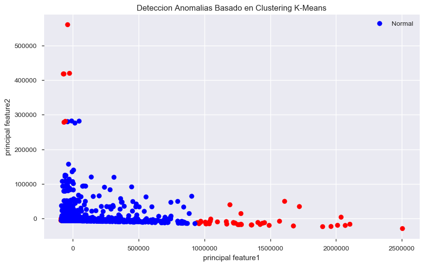

```python
#Porcion de Outliers en el Data Set
outliers_fraction = 0.05


#Distancia entre cada punto y su centroide. A mayor distancia se concidera un dato anormal
distance = getDistanceByPoint(data, km)
number_of_outliers = int(outliers_fraction*len(distance))
threshold = distance.nlargest(number_of_outliers).min()

#df2['anomalia']  Resultado de la deteccion de anomalia (0:normal, 1:anomalia)
df2 = pd.DataFrame((distance >= threshold).astype(int), columns=['anomalia'])

# visualizacion
fig, ax = plt.subplots(figsize=(10,6))
colors = {0:'blue', 1:'red'}

punto =ax.scatter(data[:,0], data[:,1],c= df2['anomalia'].apply(lambda x: colors[x]),label='Normal')
plt.xlabel('principal feature1')
plt.ylabel('principal feature2')
plt.title('Deteccion Anomalias Basado en Clustering K-Means')
plt.legend()
plt.show();
```

```python
data_full['anomalia'] =  df2['anomalia']
print('Instancias detectadas como Normal   :', data_full[data_full['anomalia'] == 0].shape[0])
print('Instancias detectadas como Anomalas :', data_full[data_full['anomalia'] == 1].shape[0])
print('Instancias Anomalas  y Clase 1      :', data_full[(data_full['anomalia'] == 1) & (data_full['class'] == 1)].shape[0])
print('Instancias Anomalas  y Clase 0      :', data_full[(data_full['anomalia'] == 1) & (data_full['class'] == 0)].shape[0])
print('Instancias Normales  y Clase 1      :', data_full[(data_full['anomalia'] == 0) & (data_full['class'] == 1)].shape[0])
print('Instancias Normales  y Clase 0      :', data_full[(data_full['anomalia'] == 0) & (data_full['class'] == 0)].shape[0])
```

```
Instancias detectadas como Normal   : 2455
Instancias detectadas como Anomalas : 129
Instancias Anomalas  y Clase 1      : 7
Instancias Anomalas  y Clase 0      : 122
Instancias Normales  y Clase 1      : 163
Instancias Normales  y Clase 0      : 2292
```

```python
data_full[data_full['anomalia'] == 1].describe()
```

|  | genergy | gpuls | gdenergy | gdpuls | nbumps | nbumps2 | nbumps3 | nbumps4 | nbumps5 | nbumps6 | nbumps7 | nbumps89 | energy | maxenergy | class | anomalia |
| --- | --- | --- | --- | --- | --- | --- | --- | --- | --- | --- | --- | --- | --- | --- | --- | --- |
| count | 1.290000e+02 | 129.000000 | 129.000000 | 129.000000 | 129.000000 | 129.000000 | 129.000000 | 129.000000 | 129.000000 | 129.0 | 129.0 | 129.0 | 129.000000 | 129.000000 | 129.000000 | 129.0 |
| mean | 4.803772e+05 | 847.147287 | -23.356589 | -24.449612 | 0.658915 | 0.255814 | 0.317829 | 0.038760 | 0.046512 | 0.0 | 0.0 | 0.0 | 15627.131783 | 15251.937984 | 0.054264 | 1.0 |
| std | 7.222603e+05 | 1251.443929 | 54.195941 | 57.665111 | 1.078889 | 0.576616 | 0.612175 | 0.193774 | 0.211411 | 0.0 | 0.0 | 0.0 | 62041.889518 | 61677.832450 | 0.227420 | 0.0 |
| min | 1.000000e+02 | 2.000000 | -96.000000 | -95.000000 | 0.000000 | 0.000000 | 0.000000 | 0.000000 | 0.000000 | 0.0 | 0.0 | 0.0 | 0.000000 | 0.000000 | 0.000000 | 1.0 |
| 25% | 1.400000e+03 | 15.000000 | -71.000000 | -72.000000 | 0.000000 | 0.000000 | 0.000000 | 0.000000 | 0.000000 | 0.0 | 0.0 | 0.0 | 0.000000 | 0.000000 | 0.000000 | 1.0 |
| 50% | 2.350000e+03 | 54.000000 | -29.000000 | -47.000000 | 0.000000 | 0.000000 | 0.000000 | 0.000000 | 0.000000 | 0.0 | 0.0 | 0.0 | 0.000000 | 0.000000 | 0.000000 | 1.0 |
| 75% | 1.132810e+06 | 1581.000000 | 13.000000 | 15.000000 | 1.000000 | 0.000000 | 0.000000 | 0.000000 | 0.000000 | 0.0 | 0.0 | 0.0 | 3000.000000 | 2000.000000 | 0.000000 | 1.0 |
| max | 2.595650e+06 | 4518.000000 | 161.000000 | 214.000000 | 5.000000 | 3.000000 | 2.000000 | 1.000000 | 1.000000 | 0.0 | 0.0 | 0.0 | 402000.000000 | 400000.000000 | 1.000000 | 1.0 |

```python
data_full[data_full['anomalia'] == 0].describe()
```

|  | genergy | gpuls | gdenergy | gdpuls | nbumps | nbumps2 | nbumps3 | nbumps4 | nbumps5 | nbumps6 | nbumps7 | nbumps89 | energy | maxenergy | class | anomalia |
| --- | --- | --- | --- | --- | --- | --- | --- | --- | --- | --- | --- | --- | --- | --- | --- | --- |
| count | 2.455000e+03 | 2455.000000 | 2455.000000 | 2455.000000 | 2455.000000 | 2455.000000 | 2455.000000 | 2455.000000 | 2455.000000 | 2455.0 | 2455.0 | 2455.0 | 2455.000000 | 2455.000000 | 2455.000000 | 2455.0 |
| mean | 6.974257e+04 | 522.365377 | 14.253360 | 6.030550 | 0.870061 | 0.400815 | 0.396741 | 0.069246 | 0.002444 | 0.0 | 0.0 | 0.0 | 4415.560081 | 3702.260692 | 0.066395 | 0.0 |
| std | 1.402259e+05 | 496.249298 | 81.033454 | 63.086559 | 1.377362 | 0.792590 | 0.777006 | 0.282777 | 0.049386 | 0.0 | 0.0 | 0.0 | 15269.946414 | 13759.458923 | 0.249022 | 0.0 |
| min | 2.600000e+03 | 7.000000 | -96.000000 | -96.000000 | 0.000000 | 0.000000 | 0.000000 | 0.000000 | 0.000000 | 0.0 | 0.0 | 0.0 | 0.000000 | 0.000000 | 0.000000 | 0.0 |
| 25% | 1.248500e+04 | 205.000000 | -35.000000 | -35.000000 | 0.000000 | 0.000000 | 0.000000 | 0.000000 | 0.000000 | 0.0 | 0.0 | 0.0 | 0.000000 | 0.000000 | 0.000000 | 0.0 |
| 50% | 2.608000e+04 | 383.000000 | -5.000000 | -5.000000 | 0.000000 | 0.000000 | 0.000000 | 0.000000 | 0.000000 | 0.0 | 0.0 | 0.0 | 0.000000 | 0.000000 | 0.000000 | 0.0 |
| 75% | 5.193000e+04 | 660.500000 | 40.000000 | 32.000000 | 1.000000 | 1.000000 | 1.000000 | 0.000000 | 0.000000 | 0.0 | 0.0 | 0.0 | 2600.000000 | 2000.000000 | 0.000000 | 0.0 |
| max | 1.018360e+06 | 3915.000000 | 1245.000000 | 838.000000 | 9.000000 | 8.000000 | 7.000000 | 3.000000 | 1.000000 | 0.0 | 0.0 | 0.0 | 208000.000000 | 200000.000000 | 1.000000 | 0.0 |

## Deteccion Anomalias Basado en IsolationForest

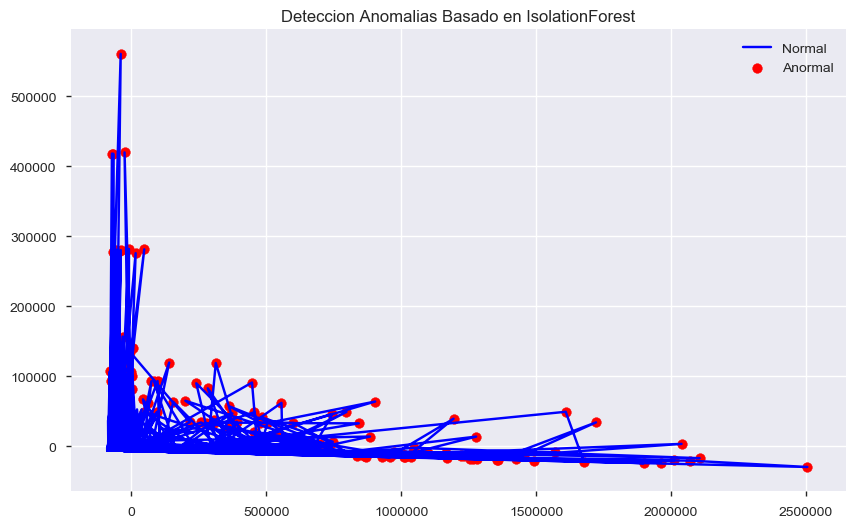

```python
model =  IsolationForest(contamination=outliers_fraction)
model.fit(data)
df2 = pd.DataFrame(pd.Series(model.predict(data)), columns=['anomaly2'])
data1 = pd.DataFrame(data, columns=['principal1','principla2'])
data1['anomaly2'] = df2

# visualization
fig, ax = plt.subplots(figsize=(10,6))
a = data1[data1['anomaly2'] == -1]
ax.plot(data[:,0], data[:,1], color='blue', label = 'Normal')
ax.scatter(a['principal1'],a['principla2'], color='red', label = 'Anormal')
plt.legend()
plt.title('Deteccion Anomalias Basado en IsolationForest')
plt.show();
```

```python
df2.size
```

```
2584
```

```python
data_full['anomalia2'] =  df2['anomaly2']
print('Instancias detectadas como Normal   :', data_full[data_full['anomalia2'] == 1].shape[0])
print('Instancias detectadas como Anomalas :', data_full[data_full['anomalia2'] == -1].shape[0])
print('Instancias Anomalas  y Clase 1      :', data_full[(data_full['anomalia2'] == -1) & (data_full['class'] == 1)].shape[0])
print('Instancias Anomalas  y Clase 0      :', data_full[(data_full['anomalia2'] == -1) & (data_full['class'] == 0)].shape[0])
print('Instancias Normales  y Clase 1      :', data_full[(data_full['anomalia2'] == 1) & (data_full['class'] == 1)].shape[0])
print('Instancias Normales  y Clase 0      :', data_full[(data_full['anomalia2'] == 1) & (data_full['class'] == 0)].shape[0])
```

```
Instancias detectadas como Normal   : 2454
Instancias detectadas como Anomalas : 130
Instancias Anomalas  y Clase 1      : 18
Instancias Anomalas  y Clase 0      : 112
Instancias Normales  y Clase 1      : 152
Instancias Normales  y Clase 0      : 2302
```

## Deteccion de Anomalias Basado en SVM

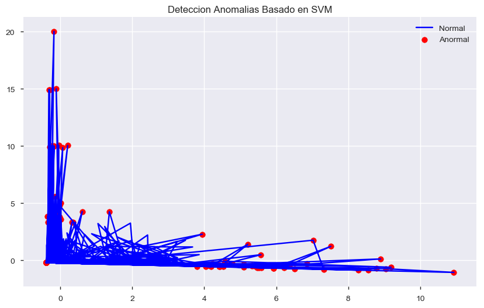

```python
scaler = StandardScaler()
data_scaled = scaler.fit_transform(data)

data1 = pd.DataFrame(data_scaled, columns=['principal1','principla2'])



# train oneclassSVM
model = OneClassSVM(nu=outliers_fraction, kernel="rbf", gamma=0.01)
model.fit(data1)
data1['anomaly3'] = pd.Series(model.predict(data1))

fig, ax = plt.subplots(figsize=(10,6))

a = data1[data1['anomaly3'] == -1]


ax.plot(data1['principal1'], data1['principla2'], color='blue', label = 'Normal')
ax.scatter(a['principal1'],a['principla2'], color='red', label = 'Anormal')
plt.title('Deteccion Anomalias Basado en SVM')
plt.legend()
plt.show();
```

```python
data_full['anomalia3'] = data1['anomaly3']
print('Instancias detectadas como Normal   :', data_full[data_full['anomalia3'] == 1].shape[0])
print('Instancias detectadas como Anomalas :', data_full[data_full['anomalia3'] == -1].shape[0])
print('Instancias Anomalas  y Clase 1      :', data_full[(data_full['anomalia3'] == -1) & (data_full['class'] == 1)].shape[0])
print('Instancias Anomalas  y Clase 0      :', data_full[(data_full['anomalia3'] == -1) & (data_full['class'] == 0)].shape[0])
print('Instancias Normales  y Clase 1      :', data_full[(data_full['anomalia3'] == 1) & (data_full['class'] == 1)].shape[0])
print('Instancias Normales  y Clase 0      :', data_full[(data_full['anomalia3'] == 1) & (data_full['class'] == 0)].shape[0])
```

```
Instancias detectadas como Normal   : 2455
Instancias detectadas como Anomalas : 129
Instancias Anomalas  y Clase 1      : 11
Instancias Anomalas  y Clase 0      : 118
Instancias Normales  y Clase 1      : 159
Instancias Normales  y Clase 0      : 2296
```

## Distribucion Anomalias por clase

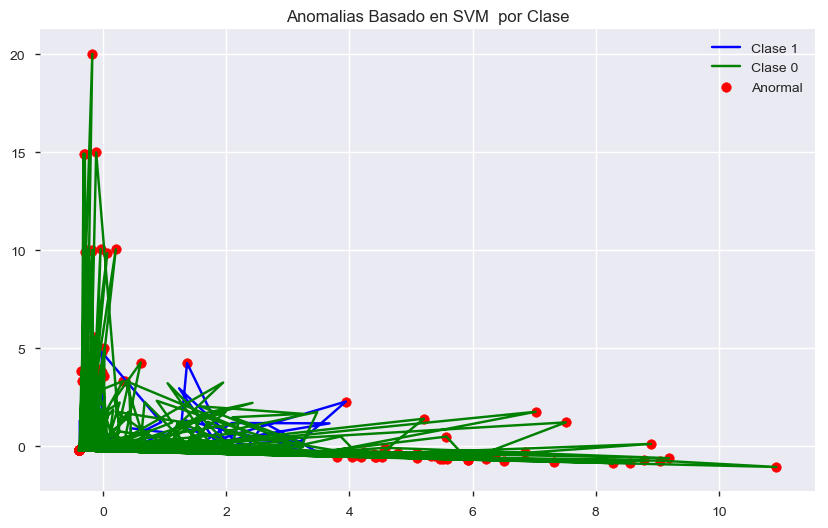

```python
#data1['labels'] = labels
data1['labels'] = data_full['class']
fig, ax = plt.subplots(figsize=(10,6))

a = data1[data1['anomaly3'] == -1]
b = data1[data1['labels'] == 1]
c = data1[data1['labels'] == 0]

ax.plot(b['principal1'], b['principla2'], color='blue', label = 'Clase 1')
ax.plot(c['principal1'], c['principla2'], color='green', label = 'Clase 0')
ax.scatter(a['principal1'],a['principla2'], color='red', label = 'Anormal')
plt.legend()
plt.title('Anomalias Basado en SVM  por Clase')
plt.show();
```

## DBSCAN - Estudent Alcohol Consumption

### Data Preparation

```python
#Data Set
df = pd.read_csv('Estudent Alcohol Consumption.csv',sep=";")

#Crea Etiqueta clase
df["Drink"] = np.where(df['Alc']<3, 0,1)
df= df.drop(['Alc'], axis=1)

#Variables correlacionadas
df['Avg'] = df[['G1', 'G2','G3']].mean(axis=1)
df= df.drop(['G1','G2','G3'], axis=1)
df_ = df.copy()

#drop atributo clase
df = df.drop(['Drink'],axis =1)

#Numerizar Variables
for c in df.columns:
        if df[c].dtype == 'object':
            lbl = preprocessing.LabelEncoder()
            lbl.fit(list(df[c].values))
            df[c] = lbl.transform(list(df[c].values))
df_num = df.copy()
#Scalar varaiables
scaler = StandardScaler()
scaler.fit(df)
StandardScaler(copy = True,with_mean=True,with_std=True)
data = scaler.transform(df)
#data
```

### Componentes PCA Data Set

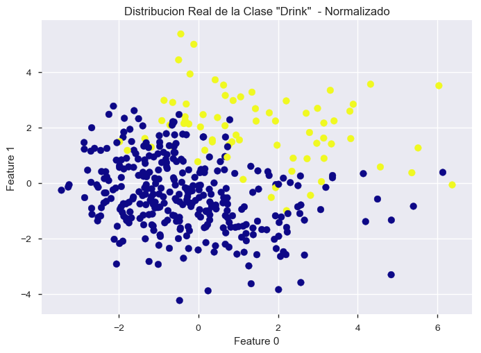

```python
#distribucion real
pca = PCA(n_components=2)
X_scaled = pca.fit_transform(data)
plt.scatter(X_scaled[:, 0], X_scaled[:, 1], c=df_['Drink'], cmap="plasma")
plt.xlabel("Feature 0")
plt.ylabel("Feature 1")
plt.title('Distribucion Real de la Clase "Drink"  - Normalizado')
```

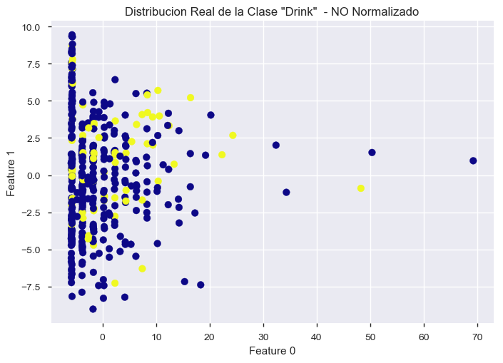

```python
pca = PCA(n_components=2)
X_scaled_ = pca.fit_transform(df_num)
plt.scatter(X_scaled_[:, 0], X_scaled_[:, 1], c=df_['Drink'], cmap="plasma")
plt.xlabel("Feature 0")
plt.ylabel("Feature 1")
plt.title('Distribucion Real de la Clase "Drink"  - NO Normalizado')
```

```
Labels del  modelo  {0, -1}
Estimated number of clusters: 1
Estimated number of noise points: 77
Homogeneity: 0.180
Completeness: 0.172
V-measure: 0.176
Adjusted Rand Index: 0.342
Adjusted Mutual Information: 0.170
Silhouette Coefficient: 0.405
ARI = 0.3422529309945516
```

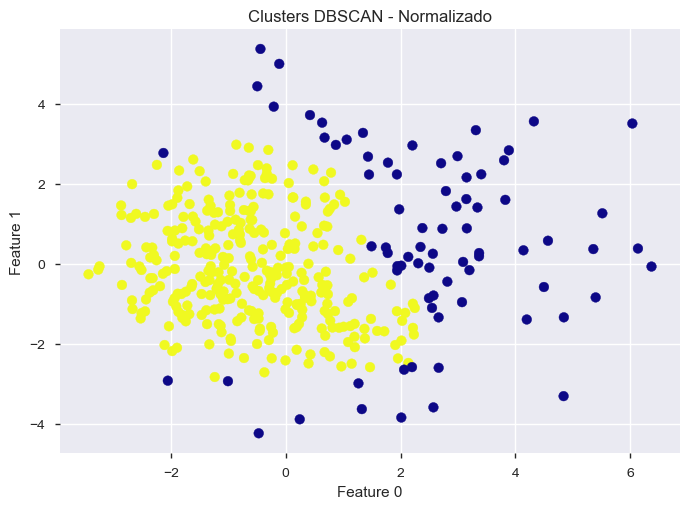

```python
#from sklearn.cluster import DBSCAN
#from sklearn.preprocessing import StandardScaler
#from sklearn.metrics.cluster import adjusted_rand_score

from sklearn import metrics

#pca = PCA(n_components=2)
#X_scaled = pca.fit_transform(data)
labels_true = df_['Drink']

# cluster
dbscan = DBSCAN(eps=0.99, min_samples = 30)
clusters = dbscan.fit_predict(X_scaled)

labels = dbscan.labels_
print ('Labels del  modelo ' ,set(labels))

core_samples = np.zeros_like(labels, dtype = bool)
core_samples[dbscan.core_sample_indices_] = True

# plot the cluster assignments
plt.scatter(X_scaled[:, 0], X_scaled[:, 1], c=clusters, cmap="plasma")
plt.xlabel("Feature 0")
plt.ylabel("Feature 1")
plt.title('Clusters DBSCAN - Normalizado')
n_clusters_ = len(set(labels)) - (1 if -1 in labels else 0)
n_noise_ = list(labels).count(-1)
print('Estimated number of clusters: %d' % n_clusters_)
print('Estimated number of noise points: %d' % n_noise_)
print("Homogeneity: %0.3f" % metrics.homogeneity_score(labels_true, labels))
print("Completeness: %0.3f" % metrics.completeness_score(labels_true, labels))
print("V-measure: %0.3f" % metrics.v_measure_score(labels_true, labels))
print("Adjusted Rand Index: %0.3f"
      % metrics.adjusted_rand_score(labels_true, labels))
print("Adjusted Mutual Information: %0.3f"
      % metrics.adjusted_mutual_info_score(labels_true, labels))
print("Silhouette Coefficient: %0.3f"
      % metrics.silhouette_score(X_scaled, labels))

#DBSCAN performance:
print("ARI =", adjusted_rand_score(labels_true, clusters))
```

```python
print("labels  0 Cluster :", labels[labels[:]==0].size)
print("labels -1 Ruido   :", labels[labels[:]==-1].size)

# Considerar ruido como tipo label = 1
labelss  = np.where(labels[:]==0, 0,1)

print("labels  Cluster 0 :",labelss[labelss[:]==0].size)
print("labels  Cluster 1 :", labelss[labelss[:]==1].size)
```

```
labels  0 Cluster : 318
labels -1 Ruido   : 77
labels  Cluster 0 : 318
labels  Cluster 1 : 77
```

```python
# Create a DataFrame with labels and varieties as columns: df
dff = pd.DataFrame({'labels': labelss, 'drink': labels_true})

# Create crosstab: ct
ct = pd.crosstab(dff['labels'],dff['drink'])
ct
```

| drink labels | 0 | 1 |
| --- | --- | --- |
| 0 | 288 | 30 |
| 1 | 36 | 41 |

### Se observa la identificacion de un cluster y 77 puntos identificados como ruido, comparado con la Distribucion Real de la Clase "Drink" - Normalizado tienen bastante grado de similitud.

### Si consideramos el ruido como cluster 1, se observa que 88.8% de los clasificados como Drink clase 0 son agrupados en el cluster 0 y 57.7 % de los clasificados como Drink clase 1 son agrupados en el cluster 1.

```
print set  {0, -1}
1
67
Estimated number of clusters: 1
Estimated number of noise points: 67
Homogeneity: 0.019
Completeness: 0.019
V-measure: 0.019
Adjusted Rand Index: 0.090
Adjusted Mutual Information: 0.016
Silhouette Coefficient: 0.045
ARI = 0.09005997545505455
```

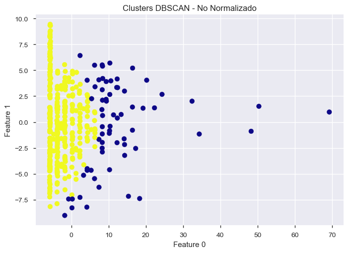

```python
labels_true = df_['Drink']

# cluster the data into five clusters
dbscan = DBSCAN(eps=2, min_samples = 15)
clusters = dbscan.fit_predict(X_scaled_)

labels = dbscan.labels_
print ('print set ' ,set(labels))

core_samples = np.zeros_like(labels, dtype = bool)
core_samples[dbscan.core_sample_indices_] = True

# plot the cluster assignments
plt.scatter(X_scaled_[:, 0], X_scaled_[:, 1], c=clusters, cmap="plasma")
plt.xlabel("Feature 0")
plt.ylabel("Feature 1")
plt.title('Clusters DBSCAN - No Normalizado')
n_clusters_ = len(set(labels)) - (1 if -1 in labels else 0)
n_noise_ = list(labels).count(-1)
print(n_clusters_)
print( n_noise_)
labels
print('Estimated number of clusters: %d' % n_clusters_)
print('Estimated number of noise points: %d' % n_noise_)
print("Homogeneity: %0.3f" % metrics.homogeneity_score(labels_true, labels))
print("Completeness: %0.3f" % metrics.completeness_score(labels_true, labels))
print("V-measure: %0.3f" % metrics.v_measure_score(labels_true, labels))
print("Adjusted Rand Index: %0.3f"
      % metrics.adjusted_rand_score(labels_true, labels))
print("Adjusted Mutual Information: %0.3f"
      % metrics.adjusted_mutual_info_score(labels_true, labels))
print("Silhouette Coefficient: %0.3f"
      % metrics.silhouette_score(X_scaled, labels))

#DBSCAN performance:
print("ARI =", adjusted_rand_score(labels_true, clusters))
```

```python
print("labels  0 Cluster :", labels[labels[:]==0].size)
print("labels -1 Ruido   :", labels[labels[:]==-1].size)

# Considerar ruido como tipo label = 1
labelss  = np.where(labels[:]==0, 0,1)

print("labels  Cluster 0 :",labelss[labelss[:]==0].size)
print("labels  Cluster 1 :", labelss[labelss[:]==1].size)
```

```
labels  0 Cluster : 328
labels -1 Ruido   : 67
labels  Cluster 0 : 328
labels  Cluster 1 : 67
```

```python
# Create a DataFrame with labels and varieties as columns: df
dff = pd.DataFrame({'labels': labelss, 'drink': labels_true})

# Create crosstab: ct
ct = pd.crosstab(dff['labels'],dff['drink'])
ct
```

| drink labels | 0 | 1 |
| --- | --- | --- |
| 0 | 277 | 51 |
| 1 | 47 | 20 |

## K-means

```python
# Comparar resultado con metodo de inicializacion : k-means++
model = KMeans(n_clusters=2,init="k-means++")

# Use fit_predict to fit model and obtain cluster labels: labels
labels = model.fit_predict(X_scaled)


# Create a DataFrame with labels and varieties as columns: df
df_0 = pd.DataFrame({'labels': labels, 'drink': df_['Drink']})

# Create crosstab: ct
ct = pd.crosstab(df_0['labels'],df_0['drink'])

# Display ct.
print(ct)
```

```
drink     0   1
labels
0       243  35
1        81  36
```

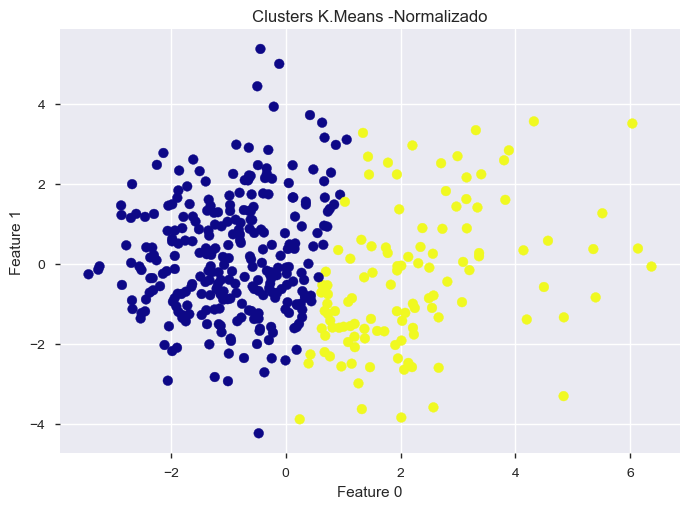

```python
plt.scatter(X_scaled[:, 0], X_scaled[:, 1], c=labels, cmap="plasma")
plt.xlabel("Feature 0")
plt.ylabel("Feature 1")
plt.title('Clusters K.Means -Normalizado')
```

### K-Means Normalizado agrupa en el cluster 1 el 75% de los de los clasificados como Drink clase 0, el 50.7% en el cluster 2 de los clasificados como Drink clase 1

```python
# Comparar resultado con metodo de inicializacion : k-means++
model = KMeans(n_clusters=2,init="k-means++")

# Use fit_predict to fit model and obtain cluster labels: labels
labels = model.fit_predict(X_scaled_)


# Create a DataFrame with labels and varieties as columns: df
df_0 = pd.DataFrame({'labels': labels, 'drink': df_['Drink']})

# Create crosstab: ct
ct = pd.crosstab(df_0['labels'],df_0['drink'])

# Display ct.
print(ct)
```

```
drink     0   1
labels
0       279  52
1        45  19
```

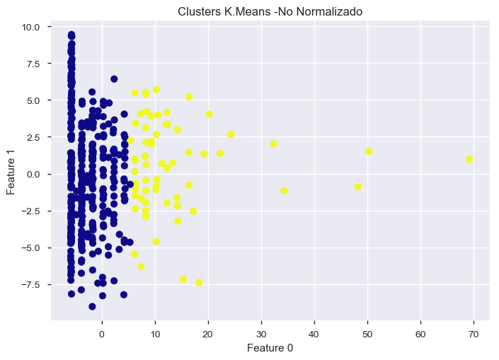

```python
plt.scatter(X_scaled_[:, 0], X_scaled_[:, 1], c=labels, cmap="plasma")
plt.xlabel("Feature 0")
plt.ylabel("Feature 1")
plt.title('Clusters K.Means -No Normalizado')
```

# Conclusiones

### En general se observa que hay mejor rendimiento con datos normalizados.

### En DBSCAN se observa un mejor desempeño frente a K-means